```python
# Run this cell to set up packages for lecture.
from lec09_imports import *
%reload_ext pandas_tutor
```

# Lecture 9 – Grouping on Multiple Columns, Merging

## DSC 10, Summer 2026

### Agenda

- Grouping on multiple columns.
- Merging.

## Grouping on multiple columns

### DSC 10 student data from Fall 2025

Last class, we looked at student name data from this quarter, where there weren't many duplicated names. Now we'll look at student name data from Fall 2025, when there were many more students and many more repeated names!

```python
roster = bpd.read_csv('data/roster-anon.csv')
roster
```

|  | name | section |
| --- | --- | --- |
| 0 | Camilla Ozqcfu | B |
| 1 | Yifan Ignjpe | A |
| 2 | Ali Jjsojh | A |
| ... | ... | ... |
| 491 | Qiankang Tzjsbb | D |
| 492 | Kim Wxnmuh | C |
| 493 | Jazmine Sxcvft | C |

494 rows × 2 columns

We know how to extract the first name of each student in the class.

```python
def first_name(full_name):
    '''Returns the first name given a full name.'''
    return full_name.split(' ')[0]
```

```python
roster = roster.assign(
    first=roster.get('name').apply(first_name)
)
roster
```

|  | name | section | first |
| --- | --- | --- | --- |
| 0 | Camilla Ozqcfu | B | Camilla |
| 1 | Yifan Ignjpe | A | Yifan |
| 2 | Ali Jjsojh | A | Ali |
| ... | ... | ... | ... |
| 491 | Qiankang Tzjsbb | D | Qiankang |
| 492 | Kim Wxnmuh | C | Kim |
| 493 | Jazmine Sxcvft | C | Jazmine |

494 rows × 3 columns

### How many students named Andrew are in each section?

```python
name_counts = (
    roster
    .groupby('first')
    .count()
    .sort_values('name', ascending=False)
    .get(['name'])
)
name_counts
```

| first | name |
| --- | --- |
| Andrew | 7 |
| Noah | 5 |
| Joseph | 5 |
| ... | ... |
| Heaven | 1 |
| Harsh | 1 |
| Ziyong | 1 |

427 rows × 1 columns

To find the number of `'Andrew'`s in each lecture section, we can query for only the rows corresponding to `'Andrew'`s, and then group by `'section'`.

```python
roster[roster.get('first') == 'Andrew'].groupby('section').count()
```

| section | name | first |
| --- | --- | --- |
| A | 1 | 1 |
| B | 3 | 3 |
| C | 1 | 1 |
| D | 2 | 2 |

But what if we want to know the number of `'Noah'`s and `'Joseph'`s per section, too?

```python
roster[roster.get('first') == 'Noah'].groupby('section').count()
```

| section | name | first |
| --- | --- | --- |
| B | 3 | 3 |
| C | 1 | 1 |
| D | 1 | 1 |

```python
roster[roster.get('first') == 'Joseph'].groupby('section').count()
```

| section | name | first |
| --- | --- | --- |
| B | 1 | 1 |
| C | 4 | 4 |

Is there a way to do this **for all first names and sections** all at once?

### How many students with each first name does each lecture section have?

- Right now, we can count the number of students with each first name, by grouping `roster` by `'first'`.

```python
# One row per unique first name.
roster.groupby('first').count().get(['name'])
```

| first | name |
| --- | --- |
| Aarush | 1 |
| Aayushi | 1 |
| Abhinav | 3 |
| ... | ... |
| Zichen | 1 |
| Zixiang | 1 |
| Ziyong | 1 |

427 rows × 1 columns

- We can also count the number of students in each lecture section, by grouping `roster` by `'section'`.

```python
# One row per unique section.
roster.groupby('section').count().get(['name'])
```

| section | name |
| --- | --- |
| A | 156 |
| B | 136 |
| C | 138 |
| D | 64 |

- However, neither of the above DataFrames gives us the number of students **with each first name** **in each section**.
  - For instance, neither result tells me the number of `'Noah'`s in section B or the number of `'Joseph'`s in section C.
- It would be nice if we could group by both `'first'` **and** `'section'` – and we can!

### Grouping on multiple columns

```python
roster
```

|  | name | section | first |
| --- | --- | --- | --- |
| 0 | Camilla Ozqcfu | B | Camilla |
| 1 | Yifan Ignjpe | A | Yifan |
| 2 | Ali Jjsojh | A | Ali |
| ... | ... | ... | ... |
| 491 | Qiankang Tzjsbb | D | Qiankang |
| 492 | Kim Wxnmuh | C | Kim |
| 493 | Jazmine Sxcvft | C | Jazmine |

494 rows × 3 columns

We can pass a **list** of column names to `.groupby`!

```python
roster.groupby(['section', 'first']).count()
```

| section | first | name |
| --- | --- | --- |
| A | Aayushi | 1 |
|  | Abhinav | 1 |
|  | Abhishai | 1 |
| ... | ... | ... |
| D | Yuting | 1 |
|  | Zhexuan | 1 |
|  | Zhong | 1 |

468 rows × 1 columns

The above DataFrame is telling us, for instance, that there is 1 student with the first name `'Aayushi'` in section A.

It is **not** saying that there is only one `'Aayushi'` in the course overall. There could be more in the other sections.

### Grouping on multiple columns

- To group on multiple columns, pass a **list** of column names to `.groupby`:

`df.groupby(['col_1', 'col_2', ..., 'col_k'])`

- Group by `'col_1'` first. **Within each group**, group by `'col_2'`, and so on.
- **Important: The resulting DataFrame has one row per unique combination of entries in the specified columns.**
  - On the previous slide, we had exactly one row for every combination of `'section'` and `'first'`.
- Formally, when we group on multiple columns, we are creating *subgroups* – that is, **groups within groups**.
  - On the previous slide, we first grouped by `'section'`, and within each section, we grouped by `'first'`.

### Notice the index... 🤔

- This is called a "[MultiIndex](https://pandas.pydata.org/pandas-docs/stable/user_guide/advanced.html)".
  - The DataFrame is indexed by `'section'` **and** `'first'`.
- We won't worry about the details of MultiIndexes.
- We can use `.reset_index()` to "flatten" our DataFrame back to normal.

```python
roster.groupby(['section', 'first']).count().reset_index()
```

|  | section | first | name |
| --- | --- | --- | --- |
| 0 | A | Aayushi | 1 |
| 1 | A | Abhinav | 1 |
| 2 | A | Abhishai | 1 |
| ... | ... | ... | ... |
| 465 | D | Yuting | 1 |
| 466 | D | Zhexuan | 1 |
| 467 | D | Zhong | 1 |

468 rows × 3 columns

### Does order matter?

```python
roster.groupby(['section', 'first']).count().reset_index()
```

|  | section | first | name |
| --- | --- | --- | --- |
| 0 | A | Aayushi | 1 |
| 1 | A | Abhinav | 1 |
| 2 | A | Abhishai | 1 |
| ... | ... | ... | ... |
| 465 | D | Yuting | 1 |
| 466 | D | Zhexuan | 1 |
| 467 | D | Zhong | 1 |

468 rows × 3 columns

```python
roster.groupby(['first', 'section']).count().reset_index()
```

|  | first | section | name |
| --- | --- | --- | --- |
| 0 | Aarush | C | 1 |
| 1 | Aayushi | A | 1 |
| 2 | Abhinav | A | 1 |
| ... | ... | ... | ... |
| 465 | Zichen | B | 1 |
| 466 | Zixiang | B | 1 |
| 467 | Ziyong | A | 1 |

468 rows × 3 columns

**Answer**: Kind of. The order of the rows and columns will be different, but the content will be the same.

### Activity

1. Using `counts`, find the lecture section with the most `'Daniel'`s.
2. Using `counts`, find the longest first name in the class that is shared by at least two students in the same section.

**✅ Click **here** to see the solutions **after** you've tried both problems.**

```
daniel_counts = counts[counts.get('first') == 'Daniel']
daniel_counts.sort_values('name', ascending=False).get('section').iloc[0]

with_len = counts.assign(length=counts.get('first').apply(len))
with_len[with_len.get('name') >= 2].sort_values('length', ascending=False).get('first').iloc[0]
```

```python
counts = roster.groupby(['section', 'first']).count().reset_index()
counts
```

|  | section | first | name |
| --- | --- | --- | --- |
| 0 | A | Aayushi | 1 |
| 1 | A | Abhinav | 1 |
| 2 | A | Abhishai | 1 |
| ... | ... | ... | ... |
| 465 | D | Yuting | 1 |
| 466 | D | Zhexuan | 1 |
| 467 | D | Zhong | 1 |

468 rows × 3 columns

### Example: Sea temperatures 🌊

[This dataset](https://library.ucsd.edu/dc/object/bb4003017c) contains the sea surface temperature in La Jolla, on many days ranging from August 22, 1916 to June 30, 2025.

```python
sea_temp = bpd.read_csv('data/sea_temp.csv')
sea_temp
```

|  | YEAR | MONTH | DAY | SURFACE_TEMP |
| --- | --- | --- | --- | --- |
| 0 | 1916 | 8 | 22 | 19.5 |
| 1 | 1916 | 8 | 23 | 19.9 |
| 2 | 1916 | 8 | 24 | 19.7 |
| ... | ... | ... | ... | ... |
| 38440 | 2025 | 6 | 28 | 22.1 |
| 38441 | 2025 | 6 | 29 | 21.7 |
| 38442 | 2025 | 6 | 30 | 20.4 |

38443 rows × 4 columns

### Concept Check ✅ – Answer at cc.dsc10.com

We want to find the single month (e.g. November 1998) with the highest average `'SURFACE_TEMP'`.

Which of the following would help us achieve this goal?

A. `sea_temp.groupby('SURFACE_TEMP').mean()`

B. `sea_temp.groupby('MONTH').mean()`

C. `sea_temp.groupby(['YEAR', 'MONTH']).mean()`

D. `sea_temp.groupby(['MONTH', 'DAY']).mean()`

E. `sea_temp.groupby(['MONTH', 'SURFACE_TEMP']).mean()`

```python
...
```

```
Ellipsis
```

### Plots of monthly and yearly average surface temperature 📈

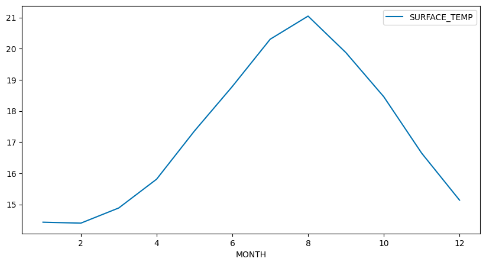

```python
(sea_temp
 .groupby('MONTH')
 .mean()
 .plot(kind='line', y='SURFACE_TEMP')
);
```

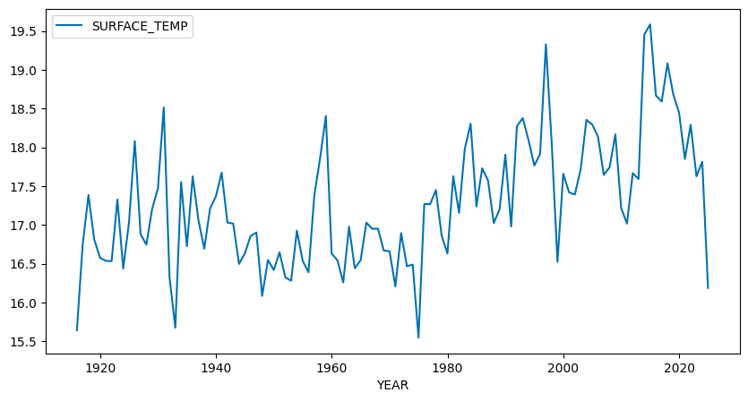

```python
# Why is there a sudden drop at the end? Look at the dates of data collection!
(sea_temp
 .groupby('YEAR')
 .mean()
 .plot(kind='line', y='SURFACE_TEMP')
);
```

### Summary: Grouping on multiple columns

- Pass a list of columns to `.groupby` to group on multiple columns. This creates groups within groups.
- Use `.reset_index()` after grouping on multiple columns to move the MultiIndex back to the columns.

## Merging 🚙

```python
offer_percentage = bpd.DataFrame().assign(
    clothing_type=['Shirt', 'Pants', 'Dress', 'Shorts', 'Shoes'],
    offer_percentage=[20, 30, 50, 30, 50]
)

clothes = bpd.DataFrame().assign(
    item=['Dress', 'Shirt', 'Shoes', 'Pants', 'Shoes'],
    retail_price=[150, 30, 90, 50, 70]
)
```

### Example: Clothing Resale 👕

```python
# The percentage of retail price that I can earn for reselling my clothes.
offer_percentage
```

|  | clothing_type | offer_percentage |
| --- | --- | --- |
| 0 | Shirt | 20 |
| 1 | Pants | 30 |
| 2 | Dress | 50 |
| 3 | Shorts | 30 |
| 4 | Shoes | 50 |

```python
# The items I want to sell and their retail prices.
clothes
```

|  | item | retail_price |
| --- | --- | --- |
| 0 | Dress | 150 |
| 1 | Shirt | 30 |
| 2 | Shoes | 90 |
| 3 | Pants | 50 |
| 4 | Shoes | 70 |

- **Question**: If I sell all of the clothes in my collection, how much will I earn?
- **Issue**: The information I need to answer the question is spread across multiple DataFrames.

### If I sell all of the clothes in my collection, how much will I earn?

```python
clothes_merged = offer_percentage.merge(clothes, left_on='clothing_type', right_on='item')
clothes_merged
```

|  | clothing_type | offer_percentage | item | retail_price |
| --- | --- | --- | --- | --- |
| 0 | Shirt | 20 | Shirt | 30 |
| 1 | Pants | 30 | Pants | 50 |
| 2 | Dress | 50 | Dress | 150 |
| 3 | Shoes | 50 | Shoes | 90 |
| 4 | Shoes | 50 | Shoes | 70 |

### What just happened!? 🤯

```python
# Click through the presentation that appears.
merging_animation()
```

[interactive chart not shown]

### `.merge`

To "merge" two DataFrames:

- Pick a "left" and "right" DataFrame.
- Choose a column from each to "merge on".

```
left_df.merge(
    right_df,
    left_on='left_col_name',
    right_on='right_col_name'
)
```

- `left_on` and `right_on` should be column names (they don't have to be the same).
- The resulting DataFrame contains a single row for every match between the two columns.
- Rows in either DataFrame without a match disappear!

### If I sell all of the clothes in my collection, how much will I earn?

```python
clothes_merged = offer_percentage.merge(clothes, left_on='clothing_type', right_on='item')
clothes_merged
```

|  | clothing_type | offer_percentage | item | retail_price |
| --- | --- | --- | --- | --- |
| 0 | Shirt | 20 | Shirt | 30 |
| 1 | Pants | 30 | Pants | 50 |
| 2 | Dress | 50 | Dress | 150 |
| 3 | Shoes | 50 | Shoes | 90 |
| 4 | Shoes | 50 | Shoes | 70 |

```python
# If I sell all of the clothes in my collection, how much will I earn?
(clothes_merged.get('offer_percentage') / 100 * clothes_merged.get('retail_price')).sum()
```

```
176.0
```

### Does it matter which DataFrame is the left or right DataFrame? 🤔

```python
offer_percentage.merge(clothes, left_on='clothing_type', right_on='item')
```

|  | clothing_type | offer_percentage | item | retail_price |
| --- | --- | --- | --- | --- |
| 0 | Shirt | 20 | Shirt | 30 |
| 1 | Pants | 30 | Pants | 50 |
| 2 | Dress | 50 | Dress | 150 |
| 3 | Shoes | 50 | Shoes | 90 |
| 4 | Shoes | 50 | Shoes | 70 |

```python
clothes.merge(offer_percentage, left_on='item', right_on='clothing_type')
```

|  | item | retail_price | clothing_type | offer_percentage |
| --- | --- | --- | --- | --- |
| 0 | Dress | 150 | Dress | 50 |
| 1 | Shirt | 30 | Shirt | 20 |
| 2 | Shoes | 90 | Shoes | 50 |
| 3 | Pants | 50 | Pants | 30 |
| 4 | Shoes | 70 | Shoes | 50 |

**Answer**: The order of the rows and columns will be different, but the content will be the same.

### Special cases

#### What if the names of the columns we want to merge on are both the same?

Instead of using `left_on='col'` and `right_on='col'`, you can just say `on='col'`.

```python
offer_percentage
```

|  | clothing_type | offer_percentage |
| --- | --- | --- |
| 0 | Shirt | 20 |
| 1 | Pants | 30 |
| 2 | Dress | 50 |
| 3 | Shorts | 30 |
| 4 | Shoes | 50 |

```python
clothes_relabeled = clothes.assign(clothing_type=clothes.get('item')).drop(columns=['item'])
clothes_relabeled
```

|  | retail_price | clothing_type |
| --- | --- | --- |
| 0 | 150 | Dress |
| 1 | 30 | Shirt |
| 2 | 90 | Shoes |
| 3 | 50 | Pants |
| 4 | 70 | Shoes |

In this example, the column we want to merge on in both DataFrames is named `'clothing_type'`, so we can just use `on='clothing_type'`.

```python
offer_percentage.merge(clothes_relabeled, on='clothing_type')
```

|  | clothing_type | offer_percentage | retail_price |
| --- | --- | --- | --- |
| 0 | Shirt | 20 | 30 |
| 1 | Pants | 30 | 50 |
| 2 | Dress | 50 | 150 |
| 3 | Shoes | 50 | 90 |
| 4 | Shoes | 50 | 70 |

**Notice**: There's only one column containing the type of clothing now.

#### What if we want to merge using an index instead of a column?

Instead of using `left_on` or `right_on`, use `left_index=True` or `right_index=True`.

```python
offers_by_item = offer_percentage.set_index('clothing_type')
offers_by_item
```

| clothing_type | offer_percentage |
| --- | --- |
| Shirt | 20 |
| Pants | 30 |
| Dress | 50 |
| Shorts | 30 |
| Shoes | 50 |

```python
clothes
```

|  | item | retail_price |
| --- | --- | --- |
| 0 | Dress | 150 |
| 1 | Shirt | 30 |
| 2 | Shoes | 90 |
| 3 | Pants | 50 |
| 4 | Shoes | 70 |

In this example, we want to merge using the index in the left DataFrame (`offers_by_item`) and the `item` column in the right DataFrame (`clothes`).

```python
offers_by_item.merge(clothes, left_index=True, right_on='item')
```

|  | offer_percentage | item | retail_price |
| --- | --- | --- | --- |
| 1 | 20 | Shirt | 30 |
| 3 | 30 | Pants | 50 |
| 0 | 50 | Dress | 150 |
| 2 | 50 | Shoes | 90 |
| 4 | 50 | Shoes | 70 |

### Concept Check ✅ – Answer at cc.dsc10.com

How many rows are in `weather.merge(schools, on='city')`?

```
A. 4    B. 5    C. 6    D. 7    E. 8
```

```python
concept_check()
```

[interactive chart not shown]

### Followup activity

How many rows are in `weather.merge(schools, on='state')`?

### More practice!

Here are related exam problems to help you practice merging:

- [Problem 5 from the Fall 2021 midterm](https://practice.dsc10.com/fa21-midterm/index.html#problem-5).
- [Problem 7 from the Fall 2022 midterm](https://practice.dsc10.com/fa22-midterm/index.html#problem-7).

## Summary, next time

### Summary

- To group on multiple columns, pass a list to `.groupby`.
  - The result has one row for every unique combination of elements in the specified columns.
- To combine information from multiple DataFrames, use `.merge`.
  - When using `.merge`, Python searches for a match between a specified column in each DataFrame and combines the rows with a match.
  - If there are no matches, the row disappears!

### Next time

- **`if`-statements**, to execute code only when certain conditions are met.
- **`for`-loops**, to repeat code many times.
- Both are foundational programming tools. 🛠